# TaylorSwift

Asbóth Hanna

2023-12-13

```r
# Reading the data

swift_raw <- readr::read_csv('https://raw.githubusercontent.com/rfordatascience/tidytuesday/master/data/2023/2023-10-17/taylor_all_songs.csv')
head(swift_raw)
```

```
## # A tibble: 6 × 29
##   album_name   ep    album_release track_number track_name      artist featuring
##   <chr>        <lgl> <date>               <dbl> <chr>           <chr>  <chr>
## 1 Taylor Swift FALSE 2006-10-24               1 Tim McGraw      Taylo… <NA>
## 2 Taylor Swift FALSE 2006-10-24               2 Picture To Burn Taylo… <NA>
## 3 Taylor Swift FALSE 2006-10-24               3 Teardrops On M… Taylo… <NA>
## 4 Taylor Swift FALSE 2006-10-24               4 A Place In Thi… Taylo… <NA>
## 5 Taylor Swift FALSE 2006-10-24               5 Cold As You     Taylo… <NA>
## 6 Taylor Swift FALSE 2006-10-24               6 The Outside     Taylo… <NA>
## # ℹ 22 more variables: bonus_track <lgl>, promotional_release <date>,
## #   single_release <date>, track_release <date>, danceability <dbl>,
## #   energy <dbl>, key <dbl>, loudness <dbl>, mode <dbl>, speechiness <dbl>,
## #   acousticness <dbl>, instrumentalness <dbl>, liveness <dbl>, valence <dbl>,
## #   tempo <dbl>, time_signature <dbl>, duration_ms <dbl>, explicit <lgl>,
## #   key_name <chr>, mode_name <chr>, key_mode <chr>, lyrics <lgl>
```

## Handling original and Taylor’s version: Creating a new column, that represents if the album is owned by Taylor Swift

Here you can read the story behind “Taylor’s verions” albums: https://www.today.com/popculture/music/taylors-version-meaning-swift-rerecording-albums-rcna98513

The list of albums that were/will be re-recorded:

‘Taylor Swift’, 2006. ‘Fearless’, 2008 – (‘Fearless – Taylor’s Version’ was released in April 2021). ‘Speak Now’, 2010 – (‘Speak Now – Taylor’s Version’ was released July 7, 2023). ‘Red’, 2012 – (‘Red – Taylor’s Version’ was released in November 2021). ‘1989’, 2014 – (‘1989 – Taylor’s Version’ released on 27th October 2023). ‘Reputation’, 2017

(source: https://www.capitalfm.com/news/taylor-swift-albums-rerecording-songs/)

```r
# Creating a row for Taylor's Vesion

swift <- swift_raw %>%
  mutate(taylors_version = ifelse(grepl("(Taylor's Version)", album_name), TRUE, FALSE))

head(swift)
```

```
## # A tibble: 6 × 30
##   album_name   ep    album_release track_number track_name      artist featuring
##   <chr>        <lgl> <date>               <dbl> <chr>           <chr>  <chr>
## 1 Taylor Swift FALSE 2006-10-24               1 Tim McGraw      Taylo… <NA>
## 2 Taylor Swift FALSE 2006-10-24               2 Picture To Burn Taylo… <NA>
## 3 Taylor Swift FALSE 2006-10-24               3 Teardrops On M… Taylo… <NA>
## 4 Taylor Swift FALSE 2006-10-24               4 A Place In Thi… Taylo… <NA>
## 5 Taylor Swift FALSE 2006-10-24               5 Cold As You     Taylo… <NA>
## 6 Taylor Swift FALSE 2006-10-24               6 The Outside     Taylo… <NA>
## # ℹ 23 more variables: bonus_track <lgl>, promotional_release <date>,
## #   single_release <date>, track_release <date>, danceability <dbl>,
## #   energy <dbl>, key <dbl>, loudness <dbl>, mode <dbl>, speechiness <dbl>,
## #   acousticness <dbl>, instrumentalness <dbl>, liveness <dbl>, valence <dbl>,
## #   tempo <dbl>, time_signature <dbl>, duration_ms <dbl>, explicit <lgl>,
## #   key_name <chr>, mode_name <chr>, key_mode <chr>, lyrics <lgl>,
## #   taylors_version <lgl>
```

```r
# Creating a list of the rerecorded albums

albums_rerecorded <- swift %>%
  filter(taylors_version == TRUE) %>%
  mutate(album_name = str_remove(album_name, fixed("(Taylor's Version)"))) %>%
  select(album_name) %>%
  unique()

print(albums_rerecorded)
```

```
## # A tibble: 2 × 1
##   album_name
##   <chr>
## 1 "Fearless "
## 2 "Red "
```

```r
# Creating a list of albums with two versions

albums_with_two_versions <- c("Fearless", "Fearless (Taylor's Version)", "Red", "Red (Taylor's Version)" )
```

## Comparing original and rerecorded albums by musical properties

I wanted to explore if there are differences between original and rerecorded songs regarding musical characteristics, such as danceability, energy, loudness, acousticness, valence, speechiness, tempo and instrumentalness,

```r
# Creating a dataset, with the rerecorded albums, and their original versions and I excluded songs, which only appear on the original or the rerecorded version

swift_original_rerecorded <- swift %>%
  filter(album_name %in% albums_with_two_versions) %>%
  mutate(track_name = str_remove(track_name, fixed(" (Taylor's Version)"))) %>%
  mutate(track_name = str_remove(track_name, fixed(" [Taylor's Version]"))) %>%
  group_by(track_name) %>%
  mutate(n = n()) %>%
  filter(n == 2) %>%
  ungroup() %>%
  select(album_name, danceability, energy, loudness, acousticness, instrumentalness, valence, speechiness, tempo)

# Descriptive statistics of each musical characteristics

describe(swift_original_rerecorded$danceability)
```

```
##    vars  n mean   sd median trimmed  mad  min  max range skew kurtosis   se
## X1    1 78 0.58 0.09   0.59    0.58 0.08 0.39 0.84  0.45 0.11    -0.11 0.01
```

```r
describe(swift_original_rerecorded$energy)
```

```
##    vars  n mean   sd median trimmed  mad  min  max range  skew kurtosis   se
## X1    1 78 0.61 0.17   0.61    0.62 0.18 0.12 0.91  0.79 -0.62     0.32 0.02
```

```r
describe(swift_original_rerecorded$loudness)
```

```
##    vars  n  mean   sd median trimmed  mad    min  max range  skew kurtosis   se
## X1    1 78 -6.47 2.21  -6.14   -6.18 1.78 -15.91 -3.1 12.81 -1.76     4.46 0.25
```

```r
describe(swift_original_rerecorded$acousticness)
```

```
##    vars  n mean   sd median trimmed  mad min  max range skew kurtosis   se
## X1    1 78 0.15 0.21   0.06     0.1 0.08   0 0.85  0.85 1.86     2.64 0.02
```

```r
describe(swift_original_rerecorded$instrumentalness)
```

```
##    vars  n mean sd median trimmed mad min  max range skew kurtosis se
## X1    1 78    0  0      0       0   0   0 0.03  0.03 8.32    69.03  0
```

```r
describe(swift_original_rerecorded$valence)
```

```
##    vars  n mean  sd median trimmed  mad  min  max range skew kurtosis   se
## X1    1 78 0.42 0.2    0.4    0.41 0.23 0.07 0.93  0.86 0.43    -0.74 0.02
```

```r
describe(swift_original_rerecorded$speechiness)
```

```
##    vars  n mean   sd median trimmed  mad  min  max range skew kurtosis se
## X1    1 78 0.04 0.02   0.03    0.03 0.01 0.02 0.17  0.15 4.68    27.58  0
```

```r
describe(swift_original_rerecorded$tempo)
```

```
##    vars  n   mean    sd median trimmed   mad   min    max range skew kurtosis
## X1    1 78 124.07 31.37 125.02  121.85 35.52 77.02 208.92 131.9 0.61    -0.11
##      se
## X1 3.55
```

Instrumentalness have a small range (min = 0, max = 0.03), so I decided, to not include it in the plot of the albums.

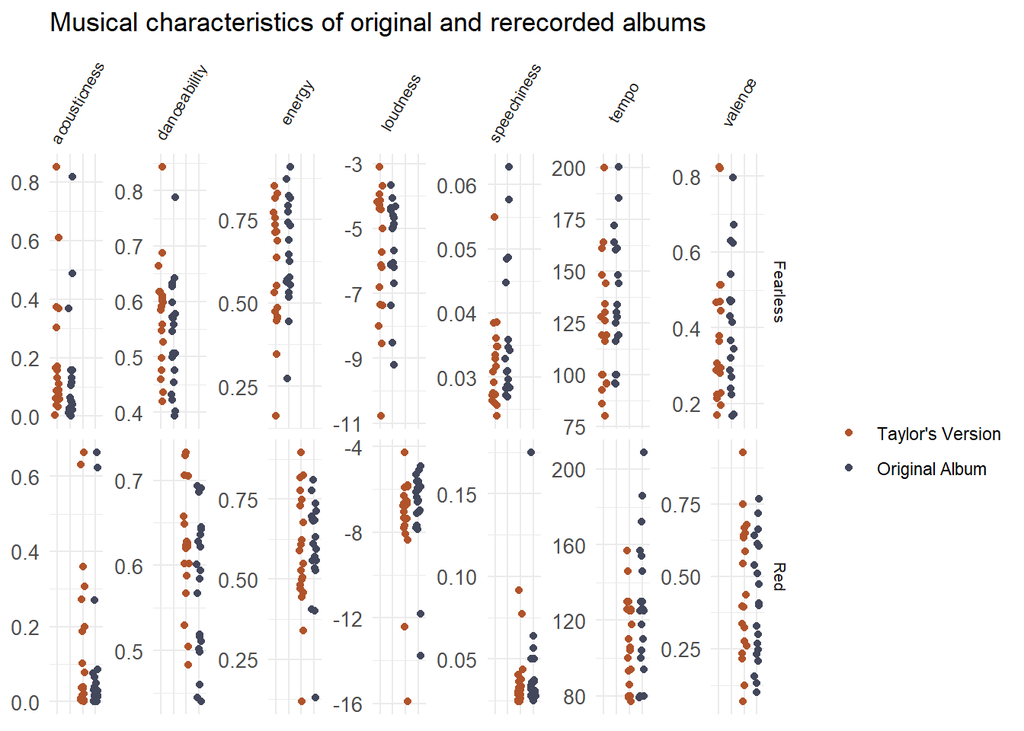

```r
# Excluding instrumentalness and transforming the data to long form, and adding the original album variable

long_swift_original_rerecorded <- swift_original_rerecorded %>%
  pivot_longer(
    cols = -c(album_name),
    names_to = "variable",
    values_to = "value"
  )


long_swift_original_rerecorded <- long_swift_original_rerecorded %>%
  mutate(taylors_version = ifelse(grepl("(Taylor's Version)", album_name), TRUE, FALSE)) %>%
  mutate(
    original_album = case_when(
      grepl("Red", album_name) ~ "Red",
      grepl("Fearless", album_name) ~ "Fearless")) %>%
  filter(variable != "instrumentalness")


# Creating a plot describing the musical characteristics, of original and rerecorded albums

ggplot(long_swift_original_rerecorded, aes(x = album_name, y = value, color = taylors_version)) +
  geom_point(position = position_jitter(width = 0.2, height = 0)) +
  theme_minimal() + # setting theme
  facet_grid2(original_album ~ variable, scales = "free_y", independent = "y", shrink = TRUE,) + # creating panels, by musical characteristics and original albums, setting free y, since the musical characteristics are ranked on different scales
  scale_y_continuous(labels = scales::comma_format()) + # setting y axis comma formatted
  labs(title = "Musical characteristics of original and rerecorded albums") + # adding title
  theme(axis.text.x = element_blank(), axis.text.y = element_text(size = 10), strip.text = element_text(size = 8, angle = 60, hjust = 0.5),
, axis.title.x = element_blank(),
    axis.title.y = element_blank() ) +  # setting text elements on the plot
  scale_color_taylor(labels = c("Taylor's Version", "Original Album")) + # adding Taylor color scale
  guides(color = guide_legend(title = " "))  # adding color guide without title
```

# Musical profile of different albums

I wanted to explore, how musical characteristics differ between all albums. I only included original albums in this analysis, and I also excluded the Holiday Collection albums, since on this album the song are covers, and I wanted to focus, on how Taylor Swift’s style changed throughout her career.

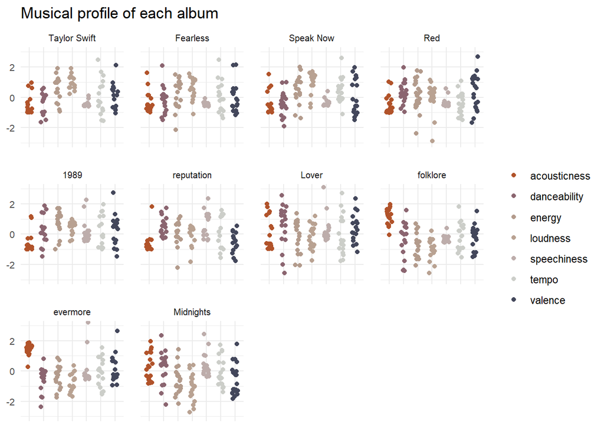

```r
# Creating a table with the original albums and excluding the Holiday Collection

swift_originals <- swift %>%
  filter(album_name != "The Taylor Swift Holiday Collection", taylors_version == FALSE) %>%
  select(album_name, danceability, energy, loudness, acousticness, valence, speechiness, tempo) %>%
  na.omit()

# Transforming the table into long format

long_swift_originals <- swift_originals %>%
  pivot_longer(cols = -album_name,
               names_to = "variable",
               values_to = "value")

# Standardizing the scales of each variable to make them more easy to compare

long_swift_originals_standardized <- long_swift_originals %>%
  group_by(variable) %>%
  mutate(value = scale(value, center = TRUE, scale = TRUE))

# Chronological order of albums

album_order <- c("Taylor Swift", "Fearless", "Speak Now", "Red", "1989", "reputation", "Lover", "folklore", "evermore", "Midnights")


# Reorder album_name based on the chronological order

long_swift_originals_standardized$album_name <- factor(
  long_swift_originals_standardized$album_name,
  levels = album_order
)

# Create the plot with reordered panels
ggplot(long_swift_originals_standardized, aes(x = variable, y = value, color = variable)) +
  geom_point(position = position_jitter(width = 0.2, height = 0)) + # creating scatter plot and setting jitter
  theme_minimal() + # adding theme minimal
  facet_wrap(~album_name, ncol = 4, shrink = TRUE) + # creating panels by album name
  theme(panel.spacing = unit(1, "lines"), strip.text = element_text(size = 8)) + # adjusting panel spacing and text size
  labs(title = "Musical profile of each album") + # adding title
  theme(axis.text.x = element_blank(), axis.text.y = element_text(size = 8), strip.text = element_text(size = 7.5), axis.title.x = element_blank(), axis.title.y = element_blank()) + # setting text elements on the plot
  scale_color_taylor() + # adding Taylor color scale
  guides(color = guide_legend(title = NULL)) + # color guide without title
  coord_cartesian(ylim = c(-3, 3)) # zooming in to make the plot more readable
```

# Exploring how albums differ by the proportion of songs in major key

Major keys in music is usually associated with happiness, while minor keys are more associated with sadness. I wanted to explore how albums differ by the proportion of song in major key, since it seemed to be a good indicator of the overall mood of the album.

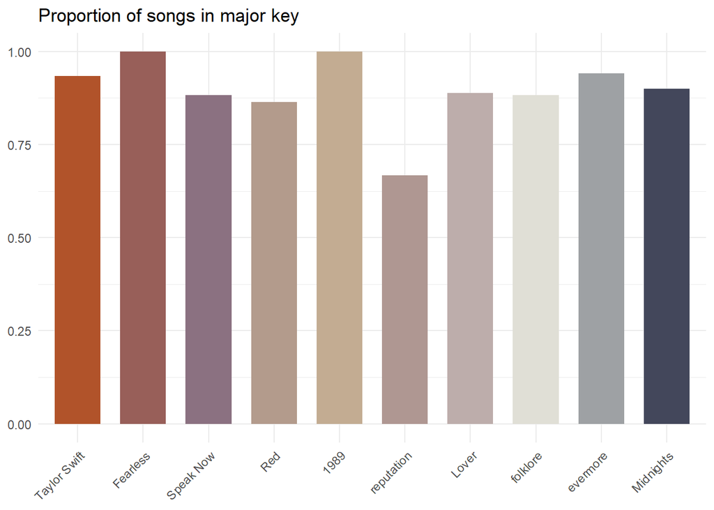

```r
# Creating a table of the original albums, and adding a column proportion of song in major key

prop_major_swift <- swift %>%
  filter(taylors_version == FALSE) %>%
  select(album_name, mode, track_number) %>%
  na.omit() %>%
  filter(album_name != "The Taylor Swift Holiday Collection") %>%
  group_by(album_name) %>%
  mutate(number_of_tracks = max(track_number)) %>%
  mutate(sum_major = sum(mode == 1)) %>%
  mutate(prop_major = sum_major/number_of_tracks)

# Ordering albums according the variable with chronological order

prop_major_swift$album_name <- factor(
  prop_major_swift$album_name,
  levels = album_order
)

# Creating a by the proportion of songs in major key

ggplot(prop_major_swift, aes(x = album_name, y = prop_major, fill = album_name)) +
  geom_bar(stat = "identity", width = 0.7, position = "dodge") +
  labs(y = NULL,
        x = NULL,
        title = "Proportion of songs in major key")+ # adding labels and title
  scale_fill_taylor() + # addig Taylor Swift color scale
  scale_x_discrete(guide = guide_axis(angle = 45)) + # adding legend title
  guides(fill = FALSE)+ # turning of color guide
  theme_minimal() # adding theme minimal
```

```r
view(prop_major_swift)
```

## Creating models to explore musical profile of albums made during the COVID quarantines

Taylor Swift created the albums titled folklore and evermore during COVID quarantines. I wanted to explore, if these album differ in their musical characteristics, from the rest of Taylor Swift’s discography.

For that I wanted to use a logistic regression model, where the predictors are different musical characteristics, and the response variable is a two level factor describing if the song was created in isolation or not.

First, I wanted to explore, how musical characteristics relate to each other.

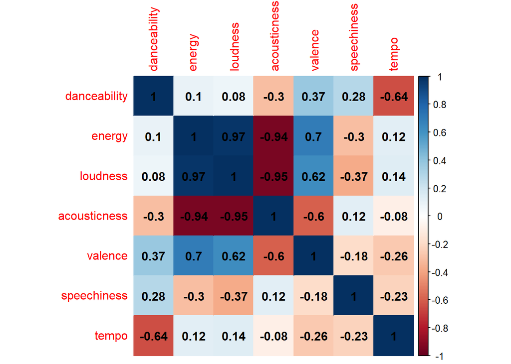

```r
# Creating a plot of correlation between musical characteristics

corrplot(cor( cor(swift_originals[, -1])), method="color", addCoef.col = "black")
```

Since there is a strong (> 0.9) correlation between energy and loudness, energy and acousticness and acousticness and loudness, I decided to use only one of them to avoid the violation of the assumption of multicollinearity.

According to the plot describing the musical profile of each album, acousticness seemed to be the variable distinguishing the albums made in isolation most, from the rest of the discography, so I decided to keep that variable.

To explore the differences between albums made during the pandemic from other albums, I to created two logistic regression models. The first, simple model only contains acousticness as a predictor, since, acourding to my explanatory analysis this seemed to be the stronger predictor. The more complex model contains other musical characteristics as well. The predictors of the complex model are: acousticness, danceability, acousticness, tempo, valence, speechiness and mode.

```r
# Creating list containing albums made during the pandemic and the rest of the discography

non_pandemic <- c("Taylor Swift", "Fearless", "Speak Now", "Red", "1989", "Lover", "Midnights", "reputation")

during_pandemic <- c("folklore", "evermore")

# Creating a table with a new variable showing if the album was made during isolation

swift_pandemic <- swift %>%
  filter(album_name != "The Taylor Swift Holiday Collection", taylors_version == FALSE) %>%
  select(album_name, track_name, danceability, acousticness, valence, speechiness, tempo, mode) %>%
  mutate(
    pandemic = case_when(
      album_name %in% non_pandemic ~ 0,
      album_name %in% during_pandemic ~ 1,
    )
  ) %>%
  na.omit()


# Building the simple and the complex model

mod_simple <- glm(pandemic ~ acousticness , data = swift_pandemic, family = "binomial")

mod_complex <- glm(pandemic ~ danceability + acousticness + valence + speechiness + tempo + mode , data = swift_pandemic, family = "binomial")
```

# Checking the assumption of linearity

```r
# Checking the assumption of linearity for the simple model

mod_simple_linearity <- glm(pandemic ~ acousticness + (acousticness:log(acousticness)),
            data=swift_pandemic,
            family=binomial(link="logit"))
logodds <- mod_simple_linearity$linear.predictors
summary(mod_simple_linearity)
```

```
##
## Call:
## glm(formula = pandemic ~ acousticness + (acousticness:log(acousticness)),
##     family = binomial(link = "logit"), data = swift_pandemic)
##
## Coefficients:
##                                Estimate Std. Error z value Pr(>|z|)
## (Intercept)                     -10.103      4.153  -2.433   0.0150 *
## acousticness                     10.821      3.800   2.848   0.0044 **
## acousticness:log(acousticness)  -10.682      6.950  -1.537   0.1243
## ---
## Signif. codes:  0 '***' 0.001 '**' 0.01 '*' 0.05 '.' 0.1 ' ' 1
##
## (Dispersion parameter for binomial family taken to be 1)
##
##     Null deviance: 172.76  on 175  degrees of freedom
## Residual deviance:  90.29  on 173  degrees of freedom
## AIC: 96.29
##
## Number of Fisher Scoring iterations: 9
```

The simple model meets the assumption of linearity.

```r
# Checking the assumption of linearity for the complex model

mod_complex_liearity <- glm(pandemic ~ danceability + (danceability:log(danceability)) + acousticness + (acousticness:log(acousticness)) + valence + (valence:log(valence)) + speechiness + (speechiness:log(speechiness)) + tempo + (tempo:log(tempo)) + mode,
            data=swift_pandemic,
            family=binomial(link="logit"))
logodds <- mod_complex_liearity$linear.predictors
summary(mod_complex_liearity)
```

```
##
## Call:
## glm(formula = pandemic ~ danceability + (danceability:log(danceability)) +
##     acousticness + (acousticness:log(acousticness)) + valence +
##     (valence:log(valence)) + speechiness + (speechiness:log(speechiness)) +
##     tempo + (tempo:log(tempo)) + mode, family = binomial(link = "logit"),
##     data = swift_pandemic)
##
## Coefficients:
##                                Estimate Std. Error z value Pr(>|z|)
## (Intercept)                    -44.1192    17.4814  -2.524 0.011610 *
## danceability                   -23.5532    11.2844  -2.087 0.036867 *
## acousticness                    15.4117     4.8257   3.194 0.001405 **
## valence                          9.8021     2.8252   3.469 0.000521 ***
## speechiness                     10.2078    15.7655   0.647 0.517321
## tempo                            2.4396     0.9039   2.699 0.006957 **
## mode                            -3.5272     1.7576  -2.007 0.044776 *
## danceability:log(danceability)  24.5048    26.4203   0.927 0.353669
## acousticness:log(acousticness) -12.9709     8.4022  -1.544 0.122648
## valence:log(valence)            -9.5606     6.2911  -1.520 0.128584
## speechiness:log(speechiness)    18.3614    14.8692   1.235 0.216882
## tempo:log(tempo)                -0.4200     0.1556  -2.699 0.006955 **
## ---
## Signif. codes:  0 '***' 0.001 '**' 0.01 '*' 0.05 '.' 0.1 ' ' 1
##
## (Dispersion parameter for binomial family taken to be 1)
##
##     Null deviance: 172.763  on 175  degrees of freedom
## Residual deviance:  56.684  on 164  degrees of freedom
## AIC: 80.684
##
## Number of Fisher Scoring iterations: 9
```

Tempo predictor in the complex model violates the assumption of linearity. Since it also has a strong correlation with danceability (r = -64), I decided to excude it from the model.

```r
# Updating the complex model

mod_complex <- glm(pandemic ~ danceability + acousticness + valence + speechiness  + mode , data = swift_pandemic, family = "binomial")

# Checking the assumption of linearity for the complex model

mod_complex_liearity <- glm(pandemic ~ danceability + (danceability:log(danceability)) + acousticness + (acousticness:log(acousticness)) + valence + (valence:log(valence)) + speechiness + (speechiness:log(speechiness)) + mode,
            data=swift_pandemic,
            family=binomial(link="logit"))
logodds <- mod_complex_liearity$linear.predictors
summary(mod_complex_liearity)
```

```
##
## Call:
## glm(formula = pandemic ~ danceability + (danceability:log(danceability)) +
##     acousticness + (acousticness:log(acousticness)) + valence +
##     (valence:log(valence)) + speechiness + (speechiness:log(speechiness)) +
##     mode, family = binomial(link = "logit"), data = swift_pandemic)
##
## Coefficients:
##                                Estimate Std. Error z value Pr(>|z|)
## (Intercept)                     -12.753     11.856  -1.076  0.28209
## danceability                     -3.525      7.518  -0.469  0.63916
## acousticness                     14.564      5.966   2.441  0.01465 *
## valence                           5.721      1.949   2.936  0.00332 **
## speechiness                      12.416     11.910   1.042  0.29720
## mode                             -2.259      1.541  -1.465  0.14279
## danceability:log(danceability)   -8.190     21.183  -0.387  0.69903
## acousticness:log(acousticness)  -14.303     10.071  -1.420  0.15556
## valence:log(valence)             -3.527      4.921  -0.717  0.47353
## speechiness:log(speechiness)     22.094     12.269   1.801  0.07174 .
## ---
## Signif. codes:  0 '***' 0.001 '**' 0.01 '*' 0.05 '.' 0.1 ' ' 1
##
## (Dispersion parameter for binomial family taken to be 1)
##
##     Null deviance: 172.763  on 175  degrees of freedom
## Residual deviance:  71.121  on 166  degrees of freedom
## AIC: 91.121
##
## Number of Fisher Scoring iterations: 10
```

```r
mod_pandemic <- glm(pandemic ~  acousticness + (acousticness:log(acousticness)),
            data=swift_pandemic,
            family=binomial(link="logit"))
logodds <- mod_pandemic$linear.predictors
summary(mod_pandemic)
```

```
##
## Call:
## glm(formula = pandemic ~ acousticness + (acousticness:log(acousticness)),
##     family = binomial(link = "logit"), data = swift_pandemic)
##
## Coefficients:
##                                Estimate Std. Error z value Pr(>|z|)
## (Intercept)                     -10.103      4.153  -2.433   0.0150 *
## acousticness                     10.821      3.800   2.848   0.0044 **
## acousticness:log(acousticness)  -10.682      6.950  -1.537   0.1243
## ---
## Signif. codes:  0 '***' 0.001 '**' 0.01 '*' 0.05 '.' 0.1 ' ' 1
##
## (Dispersion parameter for binomial family taken to be 1)
##
##     Null deviance: 172.76  on 175  degrees of freedom
## Residual deviance:  90.29  on 173  degrees of freedom
## AIC: 96.29
##
## Number of Fisher Scoring iterations: 9
```

The updated complex model meets the assumption of linearity.

#Checking outliers

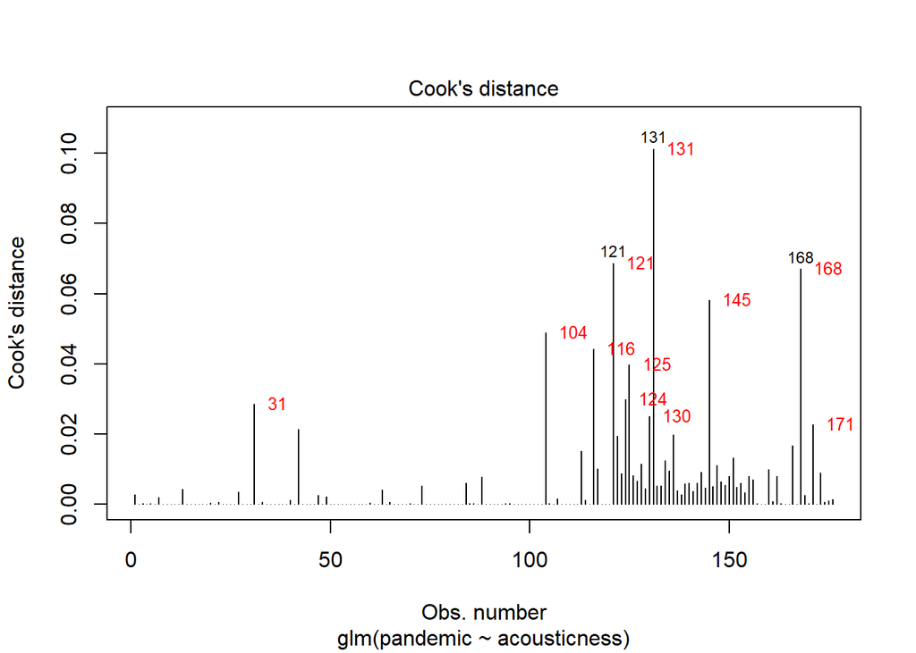

```r
# Checking for the simple model

# Calculating Cook's distance

cooksd <- cooks.distance(mod_simple)

# Plotting Cook's distance

mod_simple %>%
  plot(which = 4)

# Calculating which datapoints, have a Cook's distance greater than 4/N

influential_obs <- which(cooksd > 4 / nrow(swift_pandemic))

# Marking them on the plot

text(influential_obs, cooksd[influential_obs], labels = influential_obs, col = "red", cex = 0.8, pos = 4)
```

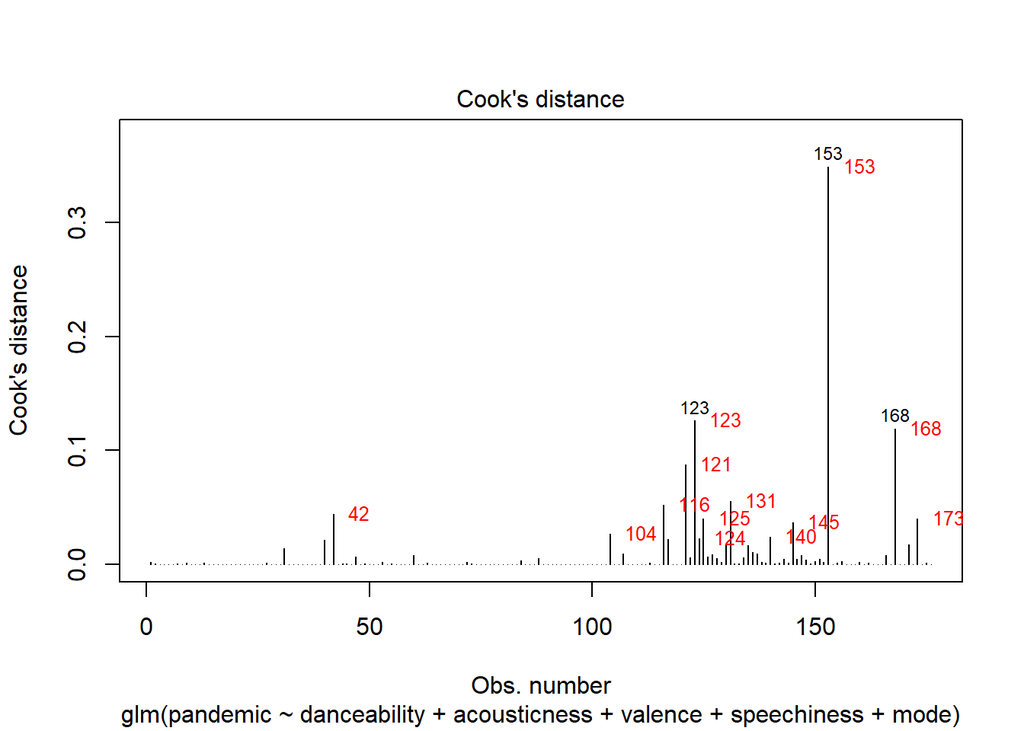

```r
# There are some data points, which have a greater Cook's distance than 4/N, but neither of them is greater than 1.

# Checking for the complex model

# Calculating Cook's distance

cooksd <- cooks.distance(mod_complex)

# Plotting Cook's distance

mod_complex %>%
  plot(which = 4)

# Calculating which datapoints, have a Cook's distance greater than 4/N

influential_obs <- which(cooksd > 4 / nrow(swift_pandemic))

# Marking them on the plot

text(influential_obs, cooksd[influential_obs], labels = influential_obs, col = "red", cex = 0.8, pos = 4)
```

```r
# There are some data points, which have a greater Cook's distance than 4/N, but neither of them is greater than 1.
```

There are no influential outliers in the models.

## Evaluating the models

For this section I used this document: https://github.com/kekecsz/PSZB17-210-Data-analysis-seminar/blob/master/seminar_10/S10_Logisztikus-regresszio.pdf

```r
summary(mod_simple)
```

```
##
## Call:
## glm(formula = pandemic ~ acousticness, family = "binomial", data = swift_pandemic)
##
## Coefficients:
##              Estimate Std. Error z value Pr(>|z|)
## (Intercept)   -4.9105     0.7876  -6.235 4.52e-10 ***
## acousticness   6.7312     1.1219   6.000 1.97e-09 ***
## ---
## Signif. codes:  0 '***' 0.001 '**' 0.01 '*' 0.05 '.' 0.1 ' ' 1
##
## (Dispersion parameter for binomial family taken to be 1)
##
##     Null deviance: 172.763  on 175  degrees of freedom
## Residual deviance:  94.447  on 174  degrees of freedom
## AIC: 98.447
##
## Number of Fisher Scoring iterations: 6
```

```r
summary(mod_complex)
```

```
##
## Call:
## glm(formula = pandemic ~ danceability + acousticness + valence +
##     speechiness + mode, family = "binomial", data = swift_pandemic)
##
## Coefficients:
##              Estimate Std. Error z value Pr(>|z|)
## (Intercept)    -1.737      1.935  -0.898  0.36919
## danceability   -5.967      2.822  -2.115  0.03447 *
## acousticness    8.223      1.505   5.465 4.62e-08 ***
## valence         4.917      1.765   2.786  0.00534 **
## speechiness   -14.402      7.532  -1.912  0.05585 .
## mode           -2.041      1.137  -1.795  0.07264 .
## ---
## Signif. codes:  0 '***' 0.001 '**' 0.01 '*' 0.05 '.' 0.1 ' ' 1
##
## (Dispersion parameter for binomial family taken to be 1)
##
##     Null deviance: 172.763  on 175  degrees of freedom
## Residual deviance:  78.906  on 170  degrees of freedom
## AIC: 90.906
##
## Number of Fisher Scoring iterations: 7
```

```r
# Creating the null model

mod_null = glm(pandemic ~ 1, family = binomial(), data = swift_pandemic)

# Calculating AIC

AIC(mod_null, mod_simple, mod_complex)
```

```
##             df       AIC
## mod_null     1 174.76297
## mod_simple   2  98.44652
## mod_complex  6  90.90606
```

```r
# Comparing models using likelihood ratio test with the null model and with each other

lrtest(mod_null, mod_simple)
```

```
## Likelihood ratio test
##
## Model 1: pandemic ~ 1
## Model 2: pandemic ~ acousticness
##   #Df  LogLik Df  Chisq Pr(>Chisq)
## 1   1 -86.381
## 2   2 -47.223  1 78.316  < 2.2e-16 ***
## ---
## Signif. codes:  0 '***' 0.001 '**' 0.01 '*' 0.05 '.' 0.1 ' ' 1
```

```r
lrtest(mod_null, mod_complex)
```

```
## Likelihood ratio test
##
## Model 1: pandemic ~ 1
## Model 2: pandemic ~ danceability + acousticness + valence + speechiness +
##     mode
##   #Df  LogLik Df  Chisq Pr(>Chisq)
## 1   1 -86.381
## 2   6 -39.453  5 93.857  < 2.2e-16 ***
## ---
## Signif. codes:  0 '***' 0.001 '**' 0.01 '*' 0.05 '.' 0.1 ' ' 1
```

```r
lrtest(mod_simple, mod_complex)
```

```
## Likelihood ratio test
##
## Model 1: pandemic ~ acousticness
## Model 2: pandemic ~ danceability + acousticness + valence + speechiness +
##     mode
##   #Df  LogLik Df Chisq Pr(>Chisq)
## 1   2 -47.223
## 2   6 -39.453  4 15.54   0.003702 **
## ---
## Signif. codes:  0 '***' 0.001 '**' 0.01 '*' 0.05 '.' 0.1 ' ' 1
```

```r
# Calculating McFadden Pseudo Rˆ2

pR2(mod_null)
```

```
## fitting null model for pseudo-r2
```

```
##       llh   llhNull        G2  McFadden      r2ML      r2CU
## -86.38148 -86.38148   0.00000   0.00000   0.00000   0.00000
```

```r
pR2(mod_simple)
```

```
## fitting null model for pseudo-r2
```

```
##         llh     llhNull          G2    McFadden        r2ML        r2CU
## -47.2232607 -86.3814831  78.3164449   0.4533173   0.3591628   0.5743922
```

```r
pR2(mod_complex)
```

```
## fitting null model for pseudo-r2
```

```
##         llh     llhNull          G2    McFadden        r2ML        r2CU
## -39.4530278 -86.3814831  93.8569107   0.5432698   0.4133213   0.6610054
```

```r
# Making predictions using the simple model

swift_pandemic = swift_pandemic %>%
  mutate(pred_mod_simple = predict(mod_simple)) %>%
  mutate(pred_mod_simple = case_when(pred_mod_simple <= 0 ~ 0,
        pred_mod_simple > 0 ~ 1))

#  Coding correct guesses
swift_pandemic = swift_pandemic %>%
  mutate(correct_prediction = case_when(pred_mod_simple == pandemic ~ "correct",
                                        pred_mod_simple != pandemic ~ "incorrect"))

# Caltulating categorization rate overall
swift_pandemic %>%
  group_by(correct_prediction) %>%
  summarise(count = n()) %>%
  mutate(freq = count / sum(count))
```

```
## # A tibble: 2 × 3
##   correct_prediction count  freq
##   <chr>              <int> <dbl>
## 1 correct              153 0.869
## 2 incorrect             23 0.131
```

```r
# Calculating proportion of correct prediction by categories

# Calculating percentage of songs made during the pandemic

swift_pandemic %>%
  group_by(pandemic) %>%
  summarise(count = n()) %>%
  mutate(freq = count / sum(count))
```

```
## # A tibble: 2 × 3
##   pandemic count  freq
##      <dbl> <int> <dbl>
## 1        0   142 0.807
## 2        1    34 0.193
```

```r
# Creating a crosstab a song was made during the pandemic and predicted values

swift_pandemic %>%
  group_by(pandemic, pred_mod_simple) %>%
  summarize(n = n()) %>%
  spread(pandemic, n)
```

```
## # A tibble: 2 × 3
##   pred_mod_simple   `0`   `1`
##             <dbl> <int> <int>
## 1               0   130    11
## 2               1    12    23
```

```r
# Calculating the proportion of cases that were correctly categorized

# Pandemic

swift_pandemic %>%
  filter(pandemic == 1) %>%
  group_by(correct_prediction) %>%
  summarise(count = n()) %>%
  mutate(freq = count / sum(count))
```

```
## # A tibble: 2 × 3
##   correct_prediction count  freq
##   <chr>              <int> <dbl>
## 1 correct               23 0.676
## 2 incorrect             11 0.324
```

```r
# Non pandemic

swift_pandemic %>%
  filter(pandemic == 0) %>%
  group_by(correct_prediction) %>%
  summarise(count = n()) %>%
  mutate(freq = count / sum(count))
```

```
## # A tibble: 2 × 3
##   correct_prediction count   freq
##   <chr>              <int>  <dbl>
## 1 correct              130 0.915
## 2 incorrect             12 0.0845
```

```r
# Making predictions using the complex model

swift_pandemic = swift_pandemic %>%
  mutate(pred_mod_complex = predict(mod_complex)) %>%
  mutate(pred_mod_complex = case_when(pred_mod_complex <= 0 ~ 0,
                                     pred_mod_complex > 0 ~ 1))

#  Coding correct guesses
swift_pandemic = swift_pandemic %>%
  mutate(correct_prediction = case_when(pred_mod_complex == pandemic ~ "correct",
                                        pred_mod_complex != pandemic ~ "incorrect"))

# Caltulating categorization rate overall
swift_pandemic %>%
  group_by(correct_prediction) %>%
  summarise(count = n()) %>%
  mutate(freq = count / sum(count))
```

```
## # A tibble: 2 × 3
##   correct_prediction count   freq
##   <chr>              <int>  <dbl>
## 1 correct              159 0.903
## 2 incorrect             17 0.0966
```

```r
# Calculating proportion of correct prediction by categories

# Creating a crosstab of if a song was made during the pandemic and predicted values

swift_pandemic %>%
  group_by(pandemic, pred_mod_complex) %>%
  summarize(n = n()) %>%
  spread(pandemic, n)
```

```
## # A tibble: 2 × 3
##   pred_mod_complex   `0`   `1`
##              <dbl> <int> <int>
## 1                0   133     8
## 2                1     9    26
```

```r
# Calculating the proportion of cases that were correctly categorized

# Pandemic

swift_pandemic %>%
  filter(pandemic == 1) %>%
  group_by(correct_prediction) %>%
  summarise(count = n()) %>%
  mutate(freq = count / sum(count))
```

```
## # A tibble: 2 × 3
##   correct_prediction count  freq
##   <chr>              <int> <dbl>
## 1 correct               26 0.765
## 2 incorrect              8 0.235
```

```r
# Non pandemic

swift_pandemic %>%
  filter(pandemic == 0) %>%
  group_by(correct_prediction) %>%
  summarise(count = n()) %>%
  mutate(freq = count / sum(count))
```

```
## # A tibble: 2 × 3
##   correct_prediction count   freq
##   <chr>              <int>  <dbl>
## 1 correct              133 0.937
## 2 incorrect              9 0.0634
```

Although the complex model showed significantly better fit, the difference in explained varience was less than 10% after adding the four other predictors to the simple model, which means that the main difference between the songs made isolation and the rest of Swift’s albums was in acousticness.